# MODELOS LINEARES GENERALIZADOS (EST082)

LISTA 4 - Dados de contagem

Autor

Jaqueline Lamas da Silva

# 5.

- quedas (número de quedas no período);
- intervenção (=0 educação somente, =1 educação e exercícios físicos);
- sexo (=0 feminino, =1 masculino);
- balanço (escore) ;
- força (escore).

**Código**

```r
suppressMessages(geriatra <- read_table("dados/lista4/geriatra.txt", col_names = FALSE))
colnames(geriatra)<-c("quedas","intervencao","sexo","balanco","forca")
geriatra$intervencao<-as.factor(geriatra$intervencao)
geriatra$sexo<-as.factor(geriatra$sexo)
```

## Análise Exploratória

**Código**

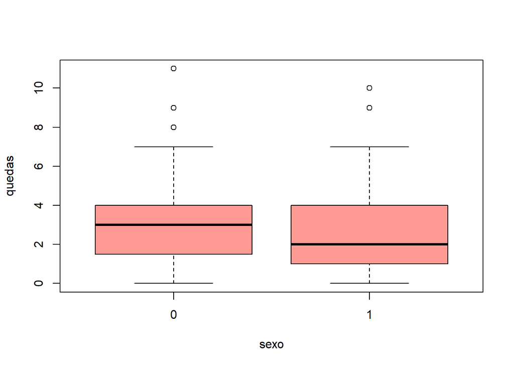

```r
suppressMessages(attach(geriatra))
boxplot(quedas~sexo, col=cores[4])
```

**Código**

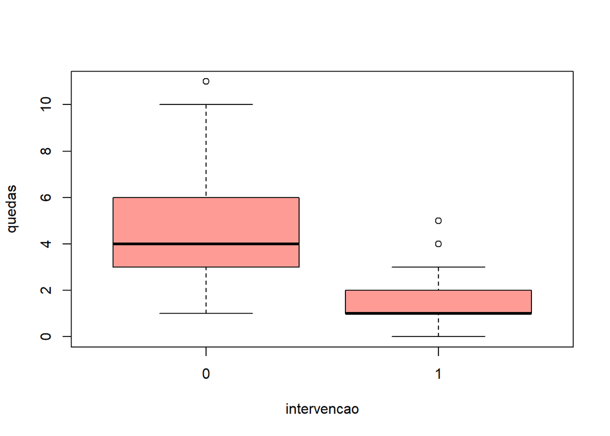

```r
boxplot(quedas~intervencao, col=cores[4])
```

Pelo boxplot as mulheres parecem apresentar mais quedas do que os homens. Além disso, podemos ver indícios de diminuição na mediana das quedas para o grupo que recebeu a intervenção com exercícios físicos.

**Código**

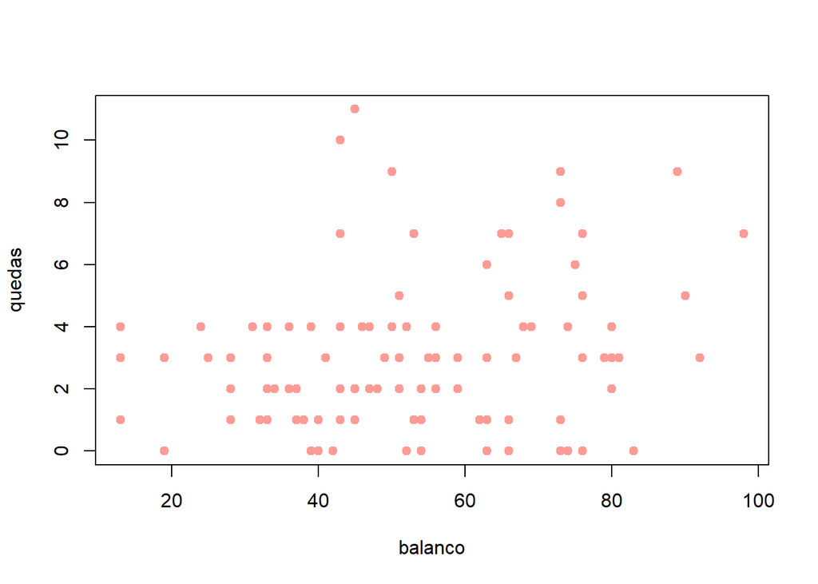

```r
plot(quedas~balanco, pch=19, col=cores[4])
```

**Código**

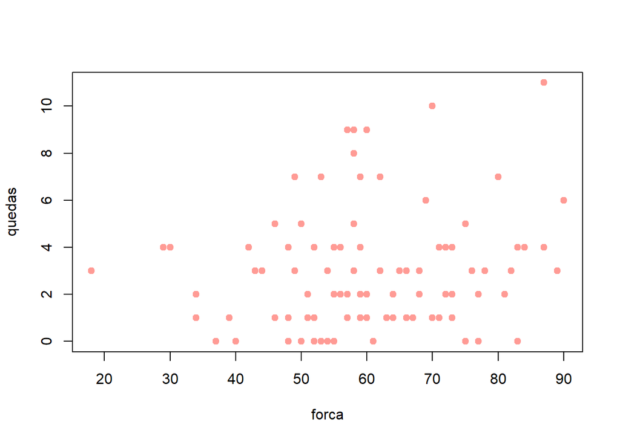

```r
plot(quedas~forca, pch=19, col=cores[4])
```

## Seleção do modelo

**Código**

```
[1] "Poisson-Link(log)"
```

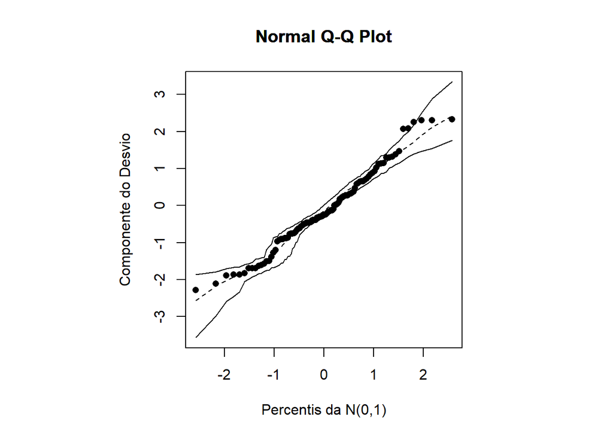

```
[1] "Poisson-Link(raiz)"
```

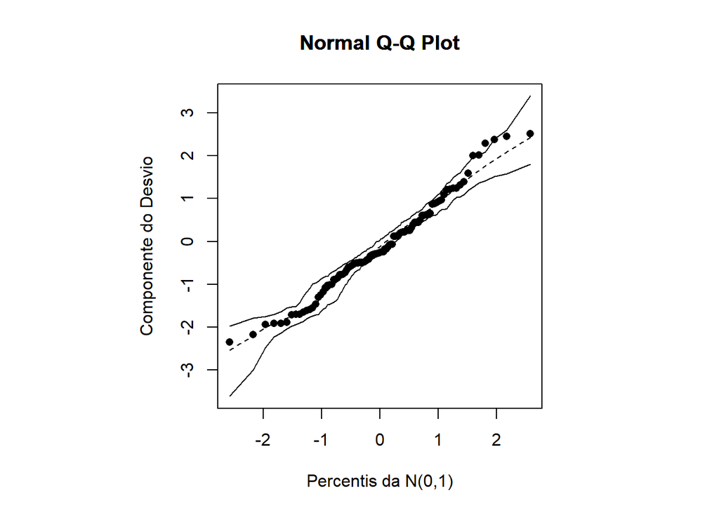

```
[1] "Poisson-Link(identity)"
```

```r
n<-nrow(geriatra)

modelo<-quedas~intervencao + sexo + forca + balanco
pois<-rbind(
ResultadosPois(geriatra, modelo, ligacao = "log", tipo ="envel_pois_log"),
ResultadosPois(geriatra, modelo, ligacao = "raiz", tipo ="envel_pois_raiz"),
ResultadosPois(geriatra, modelo, ligacao = "identity", tipo ="envel_pois")
)
```

**Código**

```r
pois |>
  arrange(BIC) |>
  knitr::kable(caption = "Melhor modelo", format ="pipe")
```

Melhor modelo

| Family | QQplot | BIC | Modelo |
| --- | --- | --- | --- |
| Poisson-Link(log) | Razoável | 385.8595 | quedas ~ intervencao + forca + balanco |
| Poisson-Link(raiz) | Razoável | 388.8913 | quedas ~ intervencao + forca + balanco |
| Poisson-Link(identity) | Não Rodou | NA | —– |

## Teste de adequação da função de ligação

**Código**

```r
modelo<-quedas~intervencao + sexo + forca + balanco
fit.model <- glm(modelo  , family=poisson(link=log))
pl2 <- predict(fit.model)^2
fit.model2<-glm(update.formula(modelo,~ . + pl2), family=poisson(link=log))
testef(fit.model,fit.model2) # fit.model(H0: pl2 não significativa) #H1: pl2 é significativa
```

```
$f
[1] 1.027594

$df1
[1] 1

$df2
[1] 94

$pvalue
[1] 0.3133267
```

Não temos evidências para rejeitar $H_0$, a função de ligação “log” é adequada para o modelo.

## Resíduos e Diagnóstico

**Código**

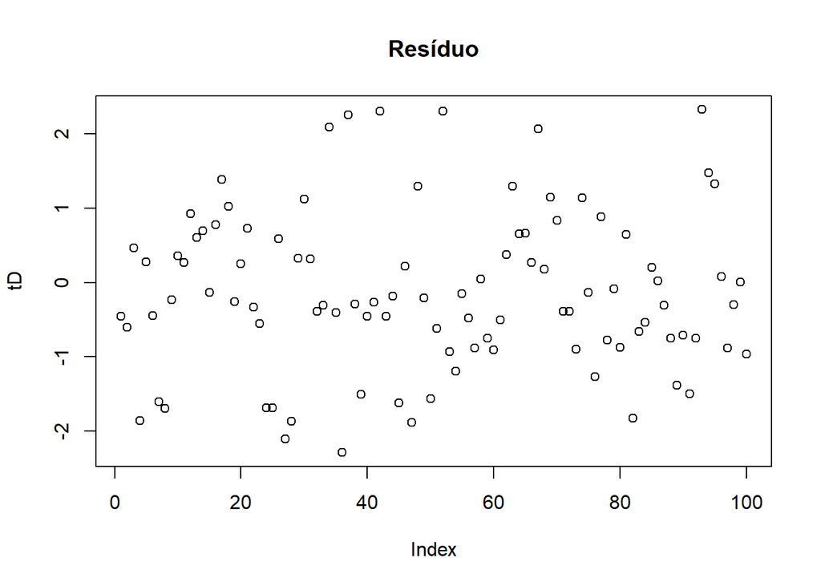

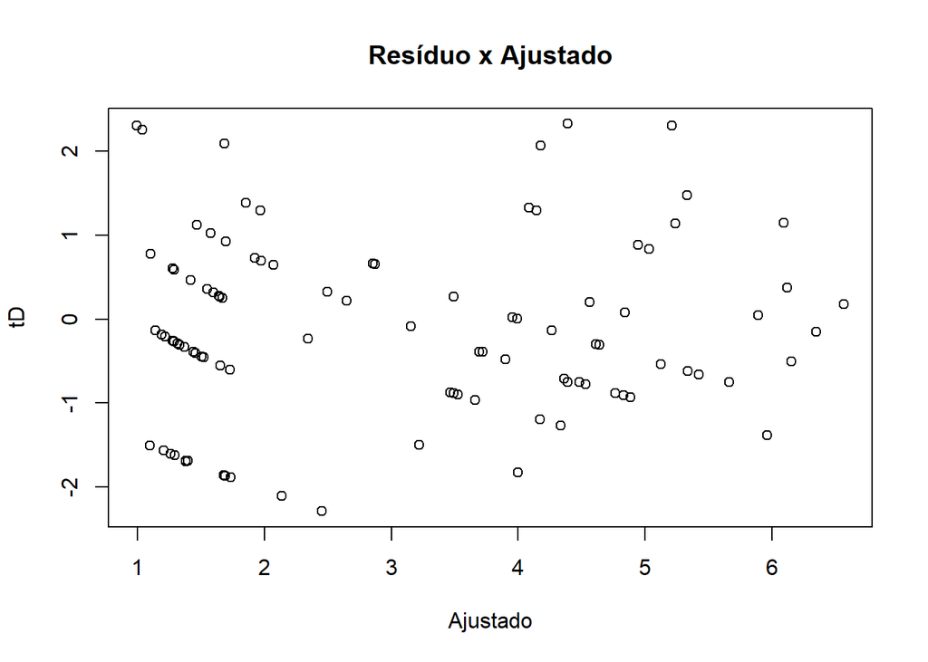

```r
modelo<-quedas~intervencao + forca + balanco
fit.model <- glm(modelo, family=poisson(link=log))

resul.resd<-residuos(fit.model)
```

**Código**

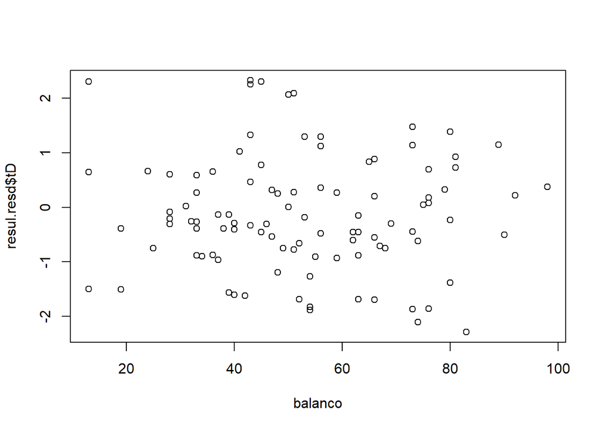

```r
plot(resul.resd$tD~balanco)
```

**Código**

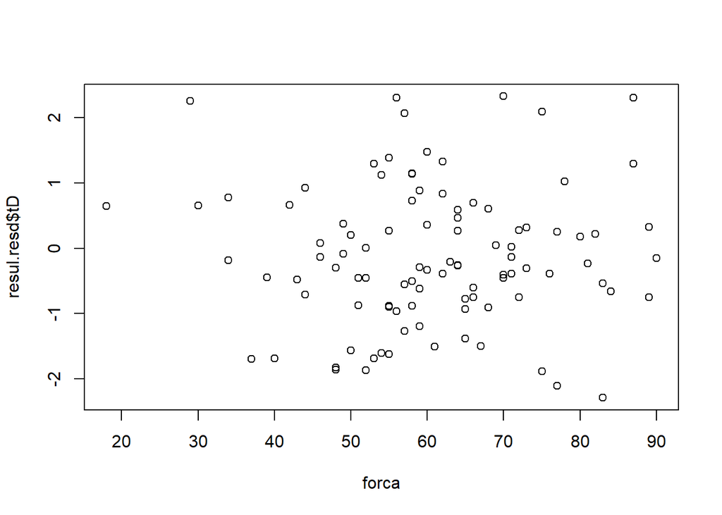

```r
plot(resul.resd$tD~forca)
```

Não foram identificados padrões nos resíduos, podemos seguir para a análise de diagnóstico.

**Código**

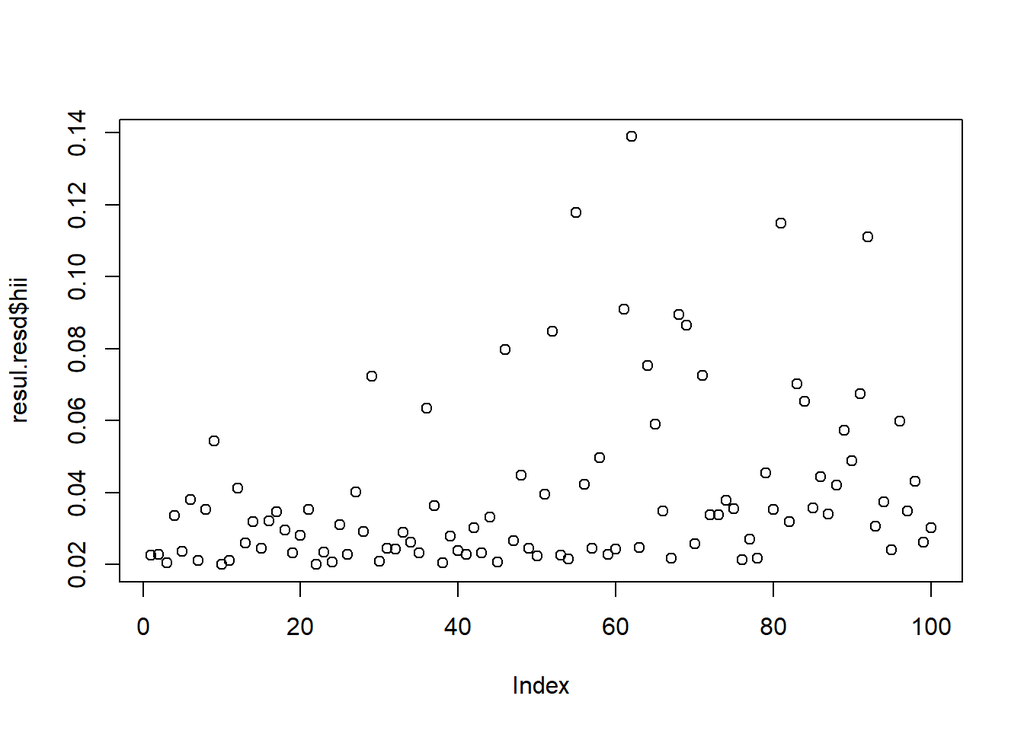

```r
plot(resul.resd$hii)
```

**Código**

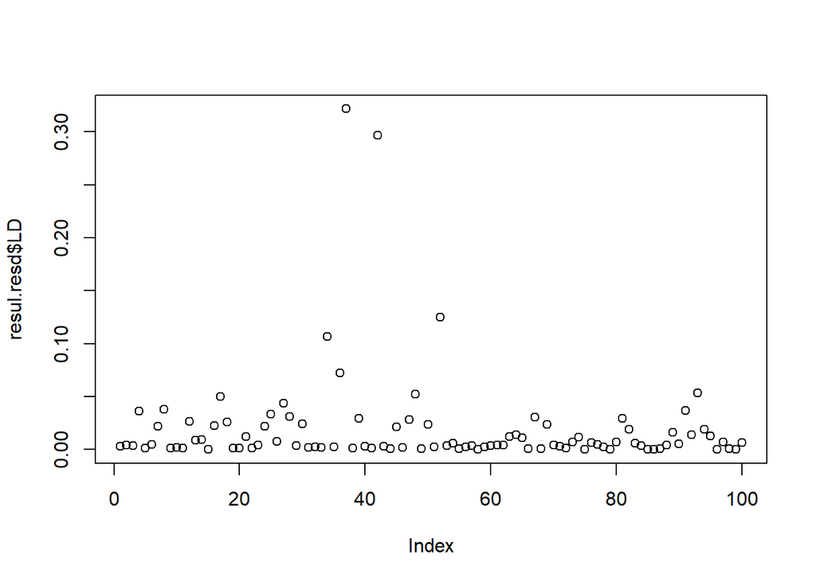

```r
plot(resul.resd$LD)
```

**Código**

```r
# > identify(resul.resd$LD,tolerance=2)
# [1] 37 42
```

**Código**

```r
geriatra[c(37,42),]
```

```
# A tibble: 2 × 5
  quedas intervencao sexo  balanco forca
   <dbl> <fct>       <fct>   <dbl> <dbl>
1      4 1           1          43    29
2      4 1           1          13    56
```

**Código**

```r
summary(quedas)
```

```
   Min. 1st Qu.  Median    Mean 3rd Qu.    Max.
   0.00    1.00    3.00    3.04    4.00   11.00
```

**Código**

```r
summary(forca)
```

```
   Min. 1st Qu.  Median    Mean 3rd Qu.    Max.
  18.00   52.00   60.00   60.78   70.25   90.00
```

**Código**

```r
summary(balanco)
```

```
   Min. 1st Qu.  Median    Mean 3rd Qu.    Max.
  13.00   39.00   51.50   52.83   66.25   98.00
```

Uma delas possui o menor valor da variável balanco e a outra possui um dos menores valores de forca.

## Interpretação

**Código**

```r
modelo<-quedas~intervencao + forca + balanco
fit.model <- glm(modelo,family=poisson(link="log"))
exp(coef(fit.model))
```

```
 (Intercept) intervencao1        forca      balanco
   1.5587593    0.3403536    1.0090196    1.0095161
```

- Os idosos que receberam a intervenção com exercícios diminuem o número médio das quedas em 66%.
- Aumentando uma unidade de força aumenta-se em média 0.9% o número de quedas.
- Aumentando uma unidade de balanço aumenta-se em média 0.96% o número de quedas.

# 7.

**Código**

```r
suppressMessages(rolos <- read_table("dados/lista4/rolos.txt",
                                     col_names = FALSE))
colnames(rolos)<-c("comprimento","falhas")
```

## Análise Exploratória

**Código**

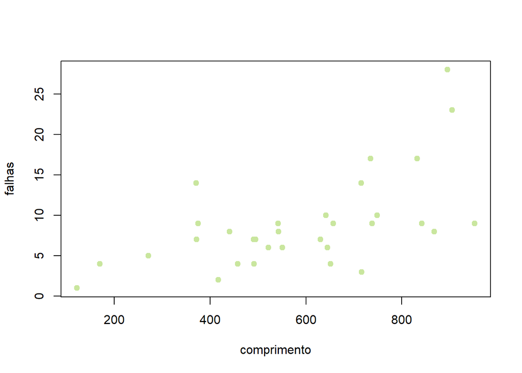

```r
suppressMessages(attach(rolos))
plot(falhas~comprimento, col=cores[2], pch=19)
```

## Seleção do modelo

**Código**

```
[1] "Poisson-Link(log)"
```

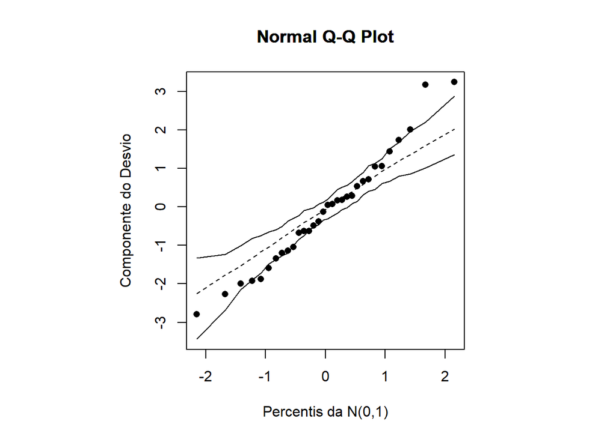

```
[1] "Poisson-Link(raiz)"
```

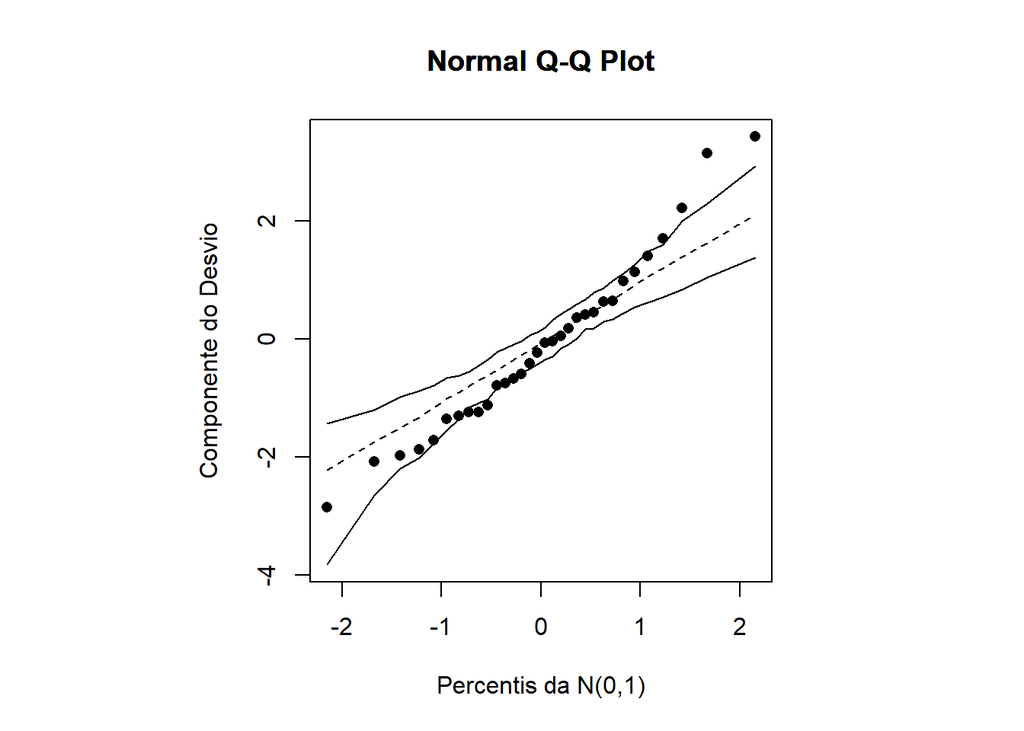

```
[1] "Poisson-Link(identity)"
```

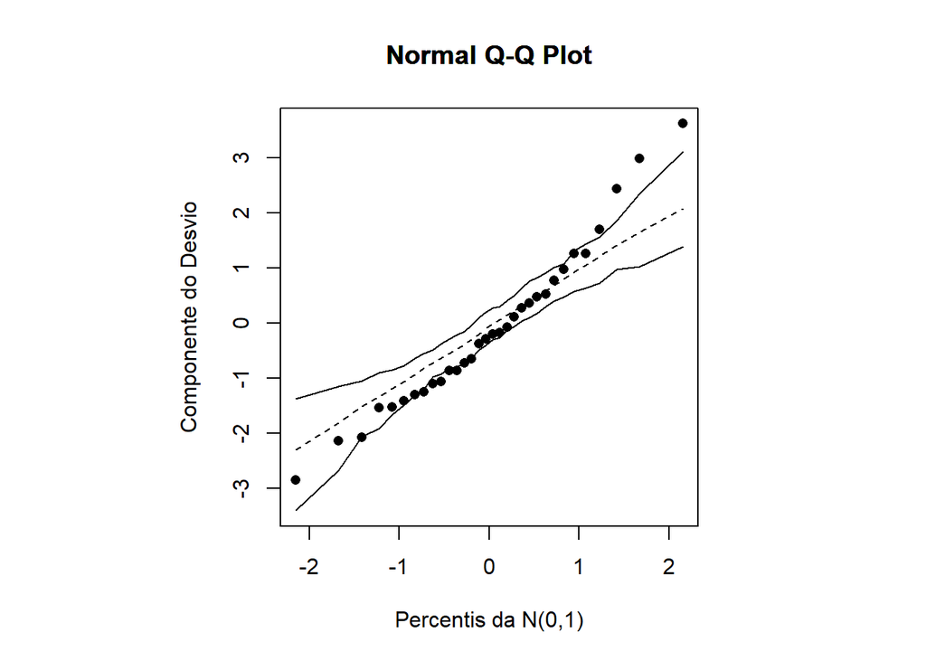

```r
n<-nrow(rolos)

modelo<-falhas~comprimento
pois<-rbind(
ResultadosPois(rolos, modelo, ligacao = "log", tipo ="envel_pois_log"),
ResultadosPois(rolos, modelo, ligacao = "raiz", tipo ="envel_pois_raiz"),
ResultadosPois(rolos, modelo, ligacao = "identity", tipo ="envel_pois")
)
```

**Código**

```r
pois |>
  arrange(BIC) |>
  knitr::kable(caption = "Melhor modelo - Poisson", format ="pipe")
```

Melhor modelo - Poisson

| Family | QQplot | BIC | Modelo |
| --- | --- | --- | --- |
| Poisson-Link(log) | Ruim | 191.9873 | falhas ~ comprimento |
| Poisson-Link(raiz) | Ruim | 193.2225 | falhas ~ comprimento |
| Poisson-Link(identity) | Ruim | 194.6801 | falhas ~ comprimento |

**Código**

```
[1] "Binomial Negativa - Link(log)"
```

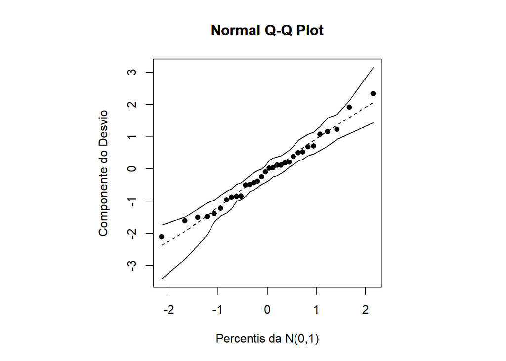

```
[1] "Binomial Negativa - Link(raiz)"
```

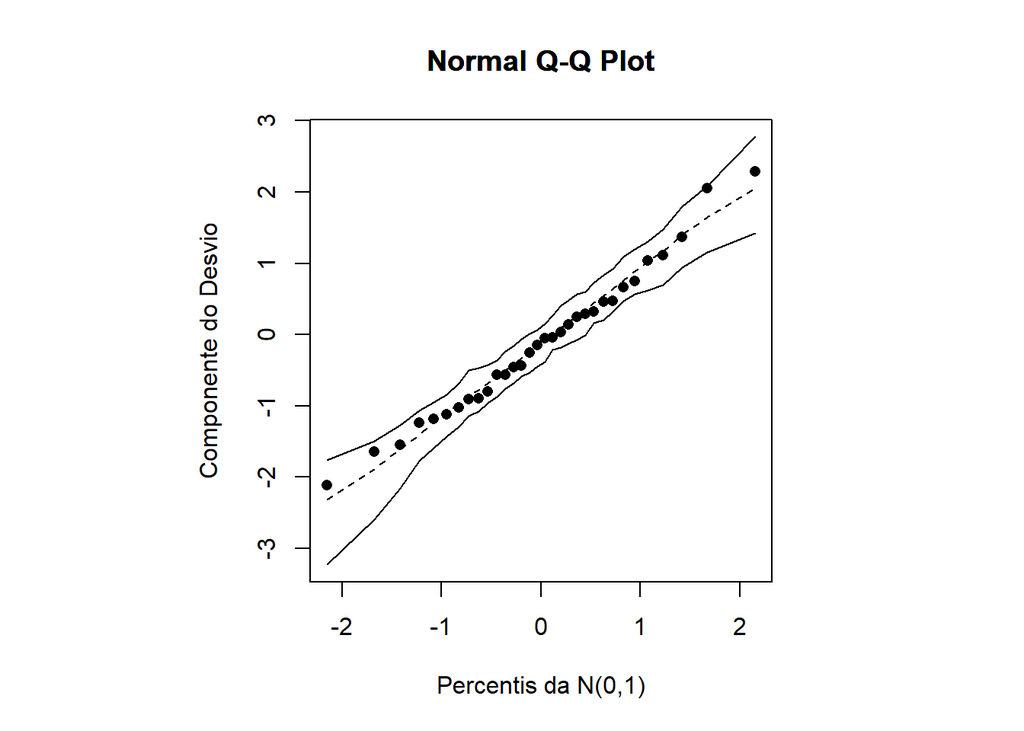

```
[1] "Binomial Negativa - Link(identity)"
```

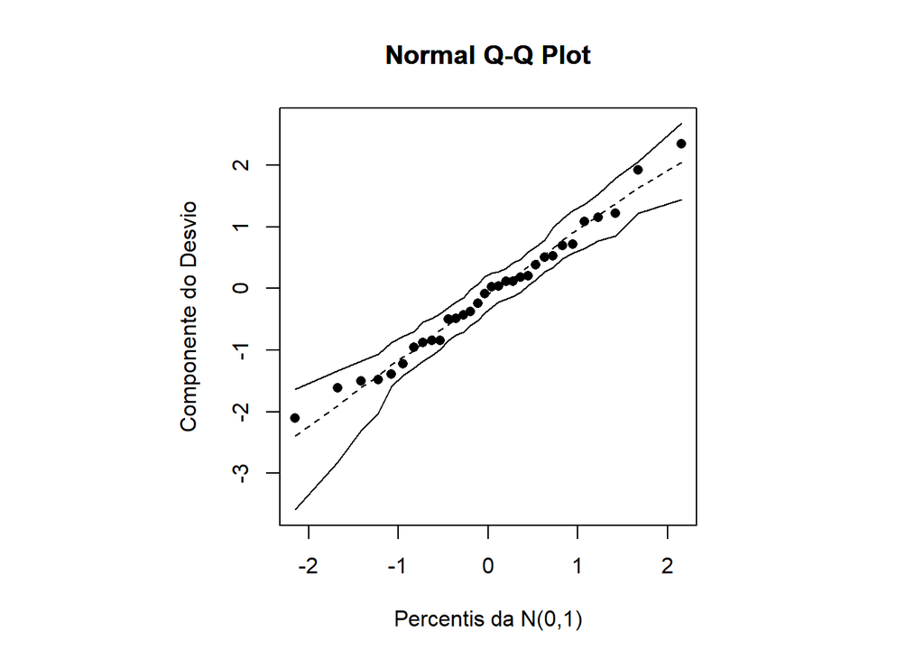

```r
bn<-rbind(
ResultadosBN(rolos, modelo, ligacao = "log", tipo ="envel_nbin_log"),
ResultadosBN(rolos, modelo, ligacao = "raiz", tipo ="envel_nbin_raiz"),
ResultadosBN(rolos, modelo, ligacao = "identity", tipo ="envel_nbin")
)
```

**Código**

```r
bn |>
  arrange(BIC) |>
  knitr::kable(caption = "Melhor modelo - Binomial Negativa", format ="pipe")
```

Melhor modelo - Binomial Negativa

| Family | QQplot | BIC | Modelo |
| --- | --- | --- | --- |
| Binomial Negativa - Link(log) | Ótimo | 184.9509 | falhas ~ comprimento |
| Binomial Negativa - Link(identity) | Ótimo | 184.9509 | falhas ~ comprimento |
| Binomial Negativa - Link(raiz) | Ótimo | 185.3602 | falhas ~ comprimento |

O modelo selecionado foi o da família binomial negativa com ligação **log**.

## Teste de adequação da função de ligação

**Código**

```r
modelo<-falhas~comprimento
fit.model <- glm.nb(modelo,link=log)
pl2 <- predict(fit.model)^2
fit.model2<-glm.nb(update.formula(modelo,~ . + pl2),link=log)
summary(fit.model2)
```

```
Call:
glm.nb(formula = update.formula(modelo, ~. + pl2), link = log,
    init.theta = 9.765094961)

Coefficients:
             Estimate Std. Error z value Pr(>|z|)
(Intercept) 1.0226512  0.2772286   3.689 0.000225 ***
comprimento 0.0003092  0.0038866   0.080 0.936597
pl2         0.1967708  0.4851894   0.406 0.685070
---
Signif. codes:  0 '***' 0.001 '**' 0.01 '*' 0.05 '.' 0.1 ' ' 1

(Dispersion parameter for Negative Binomial(9.7651) family taken to be 1)

    Null deviance: 53.232  on 31  degrees of freedom
Residual deviance: 31.449  on 29  degrees of freedom
AIC: 182.4

Number of Fisher Scoring iterations: 1

              Theta:  9.77
          Std. Err.:  5.05

 2 x log-likelihood:  -174.405
```

**Código**

```r
testef(fit.model,fit.model2) # fit.model(H0: pl2 não significativa) #H1: pl2 é significativa
```

```
$f
[1] -0.1308051

$df1
[1] 1

$df2
[1] 29

$pvalue
[1] 1
```

A função de ligação é adequada.

## Resíduos e Diagnóstico

**Código**

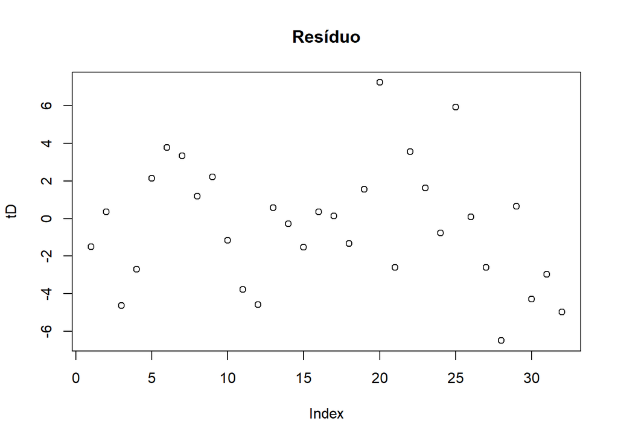

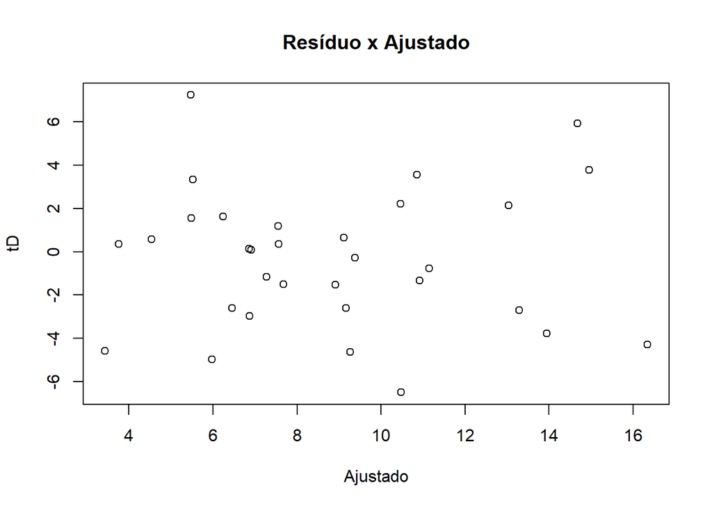

```r
modelo<-falhas~comprimento
fit.model <- glm.nb(modelo,link=log)

resul.resd<-residuosBN(fit.model)
```

**Código**

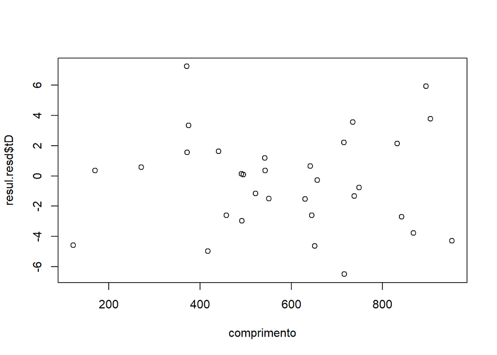

```r
plot(resul.resd$tD~comprimento)
```

Não tem nenhum padrão nos resíduos. Modelo validado.

**Código**

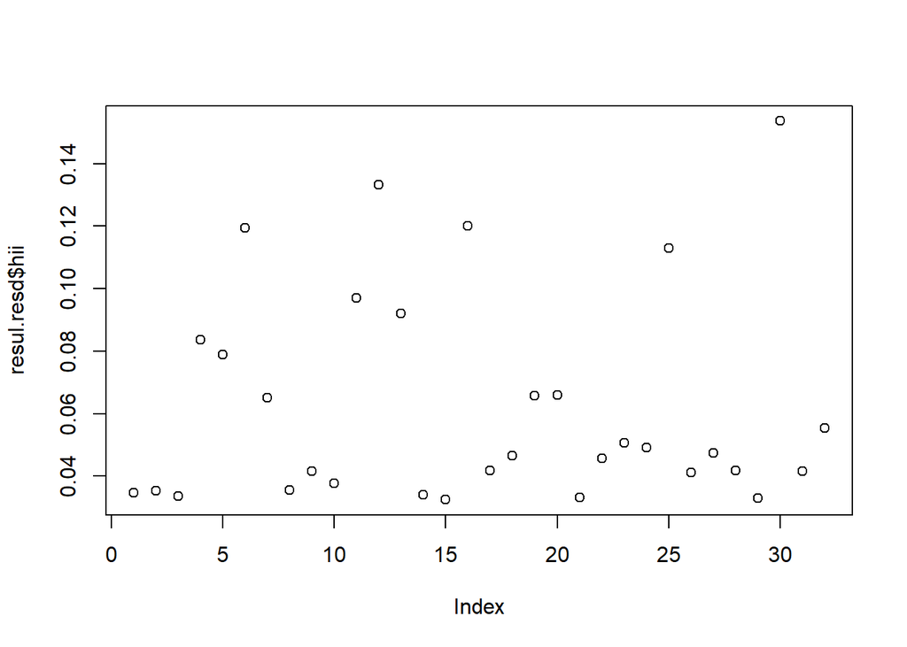

```r
plot(resul.resd$hii)
```

**Código**

```r
rolos[30,]
```

```
# A tibble: 1 × 2
  comprimento falhas
        <dbl>  <dbl>
1         952      9
```

**Código**

```r
summary(comprimento)
```

```
   Min. 1st Qu.  Median    Mean 3rd Qu.    Max.
  122.0   453.8   590.5   587.7   735.8   952.0
```

**Código**

```r
summary(falhas)
```

```
   Min. 1st Qu.  Median    Mean 3rd Qu.    Max.
  1.000   5.750   8.000   8.875   9.250  28.000
```

A observação 30 é a que apresenta maior alavanca, ela se refere à peça de tecido com maior comprimento.

**Código**

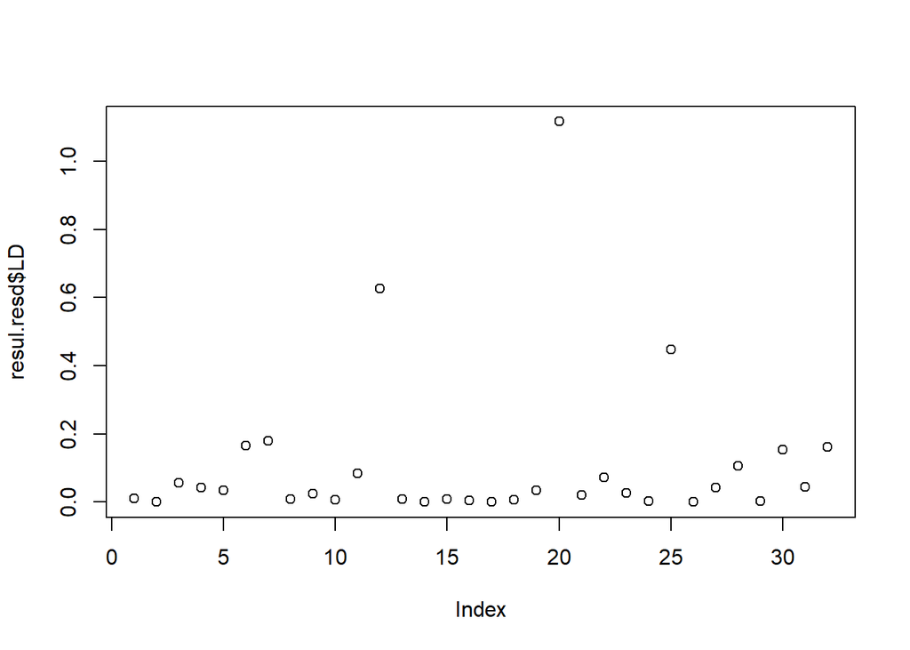

```r
plot(resul.resd$LD)
```

**Código**

```r
summary(comprimento)
```

```
   Min. 1st Qu.  Median    Mean 3rd Qu.    Max.
  122.0   453.8   590.5   587.7   735.8   952.0
```

**Código**

```r
summary(falhas)
```

```
   Min. 1st Qu.  Median    Mean 3rd Qu.    Max.
  1.000   5.750   8.000   8.875   9.250  28.000
```

**Código**

```r
rolos[20,]
```

```
# A tibble: 1 × 2
  comprimento falhas
        <dbl>  <dbl>
1         371     14
```

## Interpretação

**Código**

```r
modelo<-falhas~comprimento
fit.model <- glm.nb(modelo,link="log")
exp(coef(fit.model))
```

```
(Intercept) comprimento
   2.722271    1.001884
```

Com o aumento de uma unidade no comprimento do tecido espera-se que o número médio de falhas aumente em 0.2%.

# 15.

- hábito de nadar (ocasional ou frequente);
- local onde costuma nadar (piscina ou praia);
- faixa etária (15-19, 20-25 ou 25-29);
- sexo (masculino ou feminino);
- número de infecções de ouvido diagnosticadas pelo próprio recruta.

**Código**

```r
suppressMessages(recrutas <- read_table("dados/lista4/recrutas.txt",
                                        col_names = FALSE))
colnames(recrutas)<-c("nadar","local","idade","sexo","infeccoes")
recrutas$sexo<-as.factor(recrutas$sexo)
recrutas$nadar<-as.factor(recrutas$nadar)
recrutas$local<-as.factor(recrutas$local)
recrutas$idade<-as.factor(recrutas$idade)
```

## Análise Exploratória

**Código**

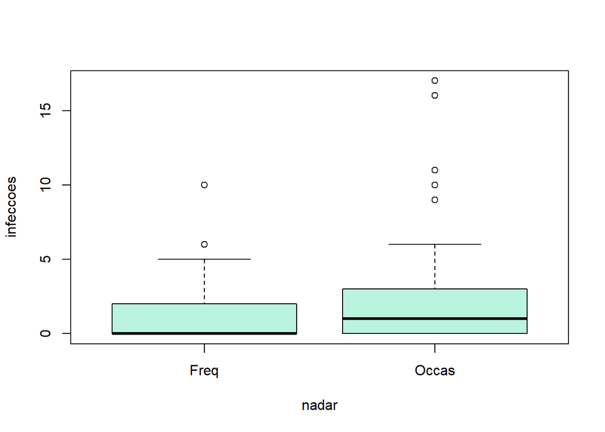

```r
suppressMessages(attach(recrutas))
boxplot(infeccoes~nadar, col=cores[1])
```

Parece que quem nada ocasionalmente tem mais chances de desenvolver infecções.

**Código**

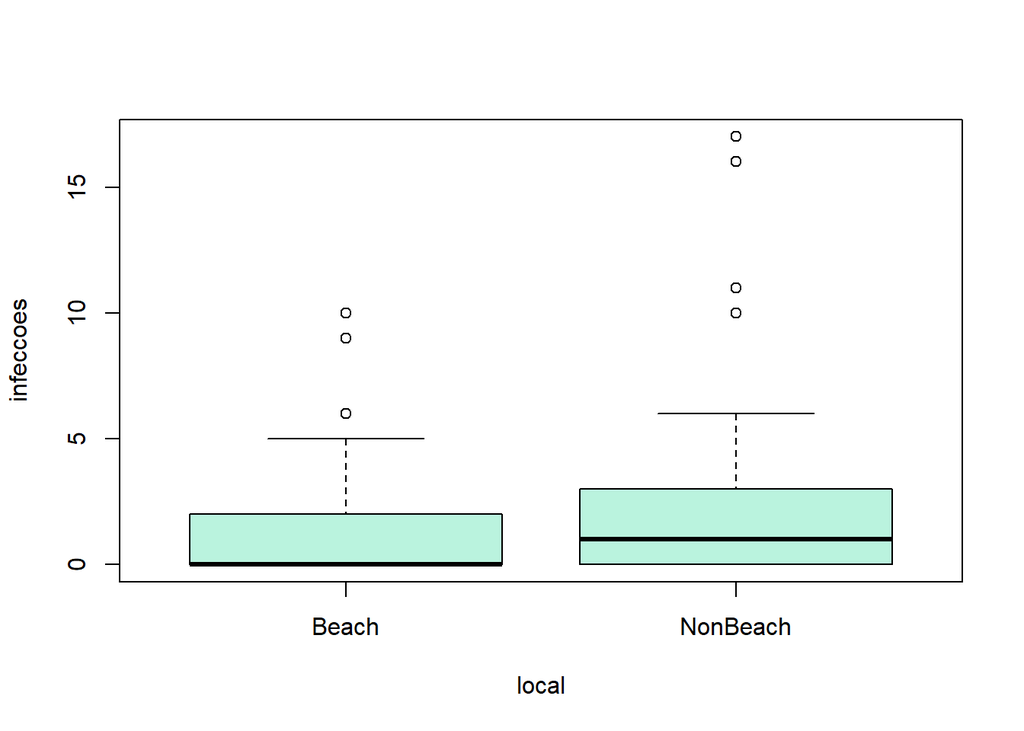

```r
boxplot(infeccoes~local, col=cores[1])
```

Aparentemente nadar na piscina apresenta mais riscos para infecção de ouvido.

**Código**

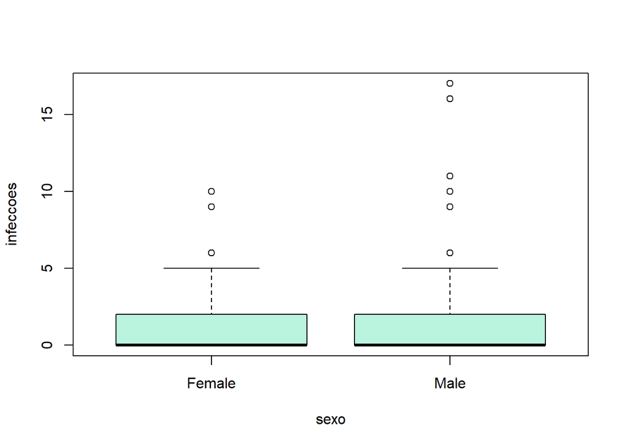

```r
boxplot(infeccoes~sexo, col=cores[1])
```

**Código**

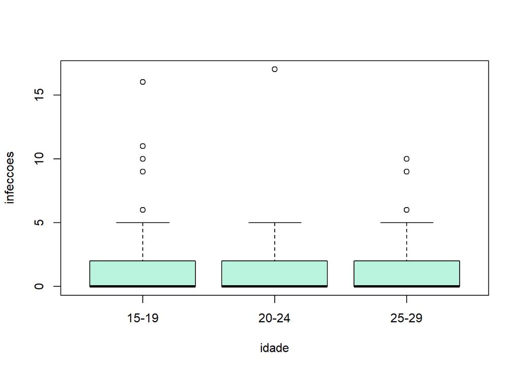

```r
boxplot(infeccoes~idade, col=cores[1])
```

Idade e sexo não parecem estar associadadas ao número de infecções.

## Seleção do modelo

**Código**

```
[1] "Poisson-Link(log)"
```

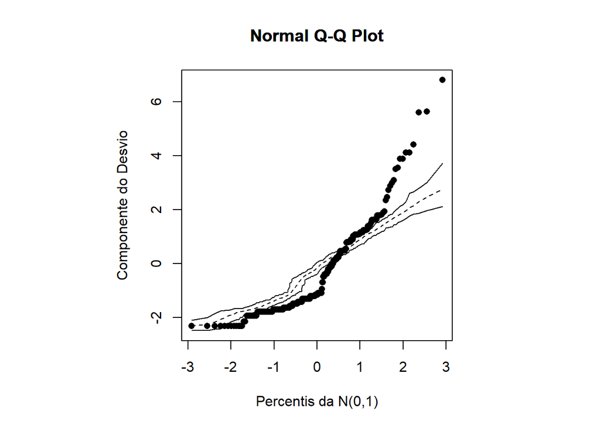

```
[1] "Poisson-Link(raiz)"
```

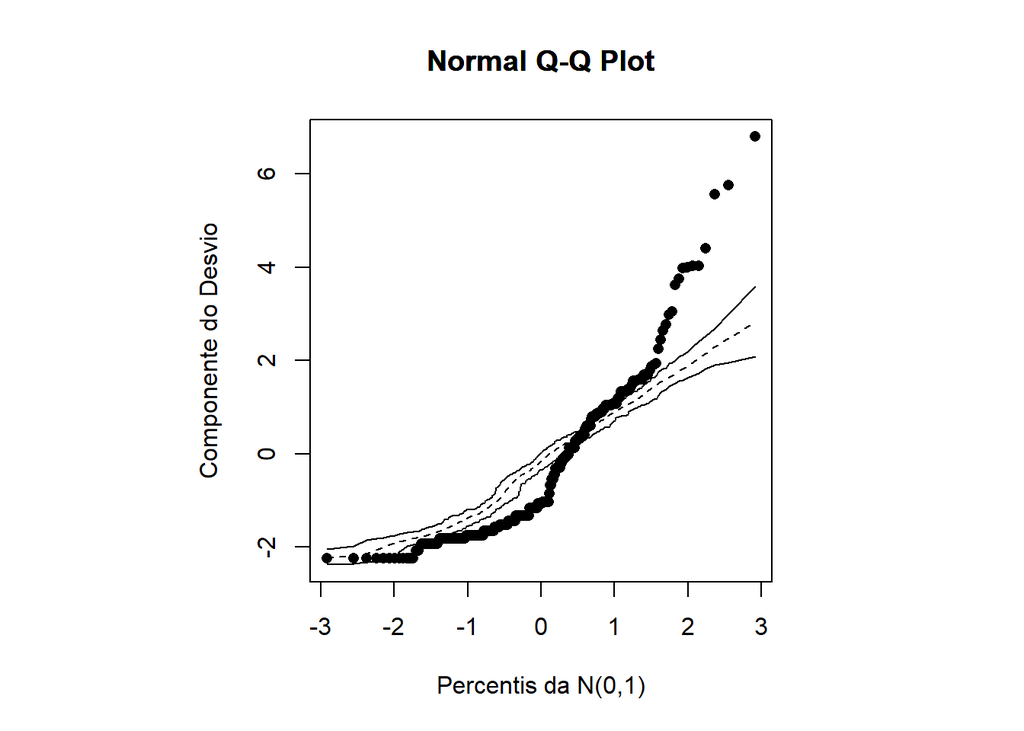

```
[1] "Poisson-Link(identity)"
```

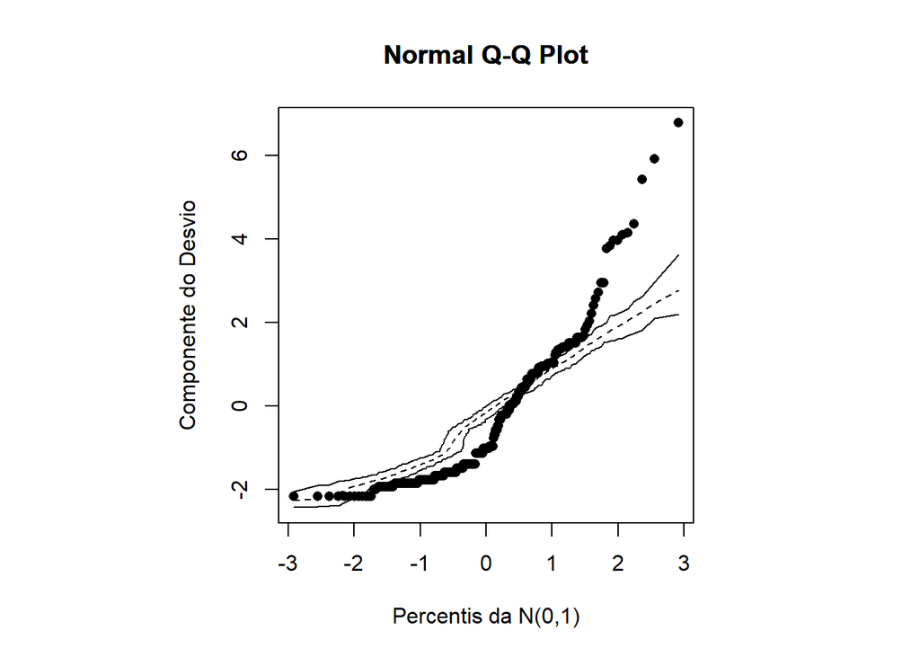

```r
n<-nrow(recrutas)

modelo<-infeccoes~idade+sexo+local+nadar
pois<-rbind(
ResultadosPois(recrutas, modelo, ligacao = "log", tipo ="envel_pois_log"),
ResultadosPois(recrutas, modelo, ligacao = "raiz", tipo ="envel_pois_raiz"),
ResultadosPois(recrutas, modelo, ligacao = "identity", tipo ="envel_pois")
)
```

**Código**

```r
pois |>
  arrange(BIC) |>
  knitr::kable(caption = "Melhor modelo - Poisson", format ="pipe")
```

Melhor modelo - Poisson

| Family | QQplot | BIC | Modelo |
| --- | --- | --- | --- |
| Poisson-Link(log) | Ruim | 1144.061 | infeccoes ~ idade + local + nadar |
| Poisson-Link(raiz) | Ruim | 1145.194 | infeccoes ~ idade + local + nadar |
| Poisson-Link(identity) | Ruim | 1148.262 | infeccoes ~ idade + local + nadar |

**Código**

```
[1] "Binomial Negativa - Link(log)"
```

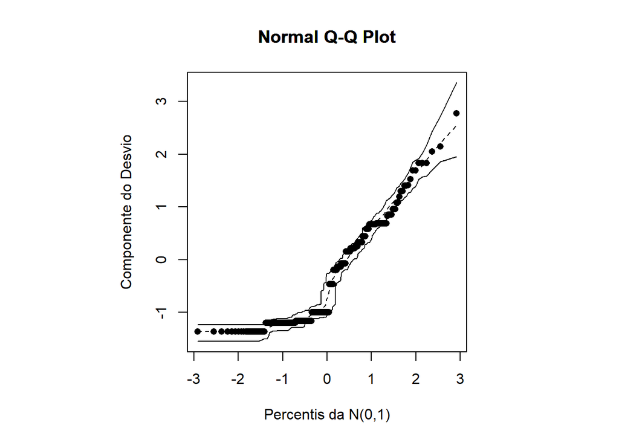

```
[1] "Binomial Negativa - Link(raiz)"
```

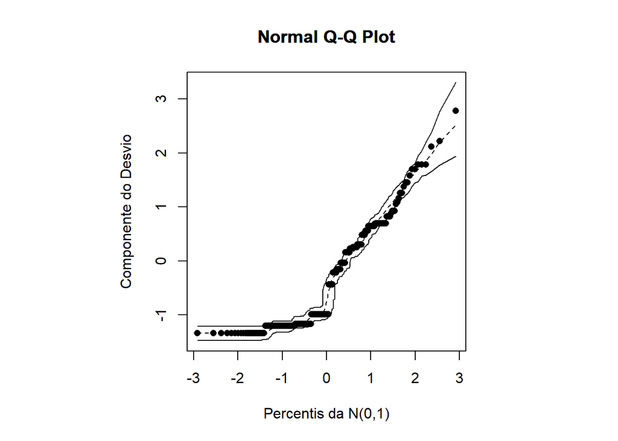

```
[1] "Binomial Negativa - Link(identity)"
```

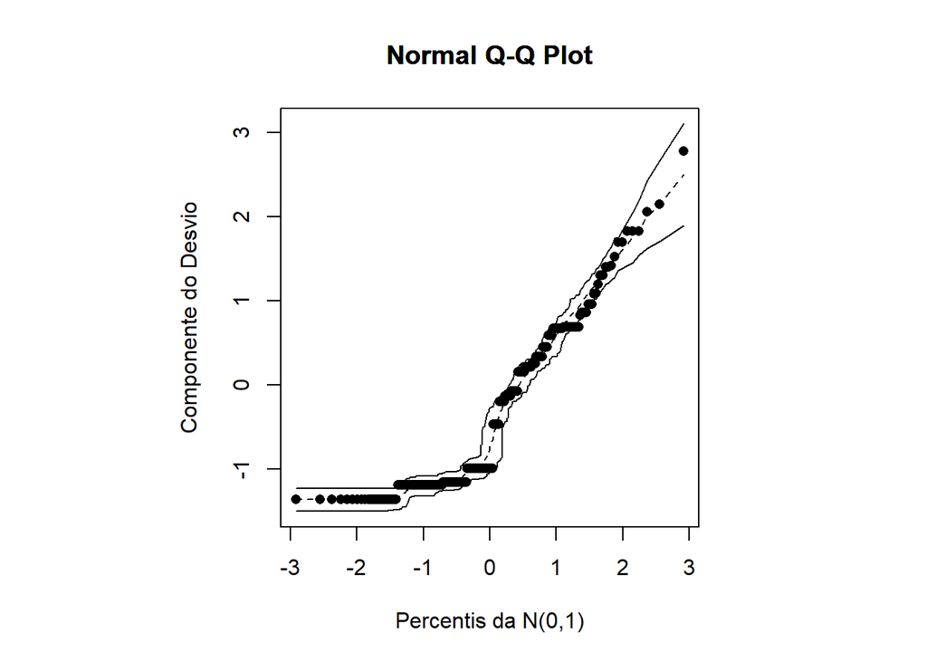

```r
bn<-rbind(
ResultadosBN(recrutas, modelo, ligacao = "log", tipo ="envel_nbin_log"),
ResultadosBN(recrutas, modelo, ligacao = "raiz", tipo ="envel_nbin_raiz"),
ResultadosBN(recrutas, modelo, ligacao = "identity", tipo ="envel_nbin")
)
```

**Código**

```r
bn |>
  arrange(BIC) |>
  knitr::kable(caption = "Melhor modelo - Binomial Negativa", format ="pipe")
```

Melhor modelo - Binomial Negativa

| Family | QQplot | BIC | Modelo |
| --- | --- | --- | --- |
| Binomial Negativa - Link(log) | Razoável | 910.6111 | infeccoes ~ local + nadar |
| Binomial Negativa - Link(identity) | Razoável | 910.6111 | infeccoes ~ local + nadar |
| Binomial Negativa - Link(raiz) | Razoável | 911.2703 | infeccoes ~ local + nadar |

O modelo selecionado foi o da família Binomial Negativa com ligação identidade.

## Teste de adequação da função de ligação

**Código**

```r
modelo<-infeccoes ~ local + nadar
fit.model <- glm.nb(modelo,link=identity)
pl2 <- predict(fit.model)^2
fit.model2<-glm.nb(update.formula(modelo,~ . + pl2),link=identity)
summary(fit.model2)
```

```
Call:
glm.nb(formula = update.formula(modelo, ~. + pl2), link = identity,
    init.theta = 0.5813399904)

Coefficients:
              Estimate Std. Error z value Pr(>|z|)
(Intercept)     0.2437     0.4165   0.585    0.558
localNonBeach  -0.8225     0.9976  -0.824    0.410
nadarOccas     -1.1461     1.3411  -0.855    0.393
pl2             0.9974     0.7253   1.375    0.169

(Dispersion parameter for Negative Binomial(0.5813) family taken to be 1)

    Null deviance: 284.18  on 281  degrees of freedom
Residual deviance: 267.15  on 278  degrees of freedom
AIC: 897.46

Number of Fisher Scoring iterations: 1

              Theta:  0.5813
          Std. Err.:  0.0912

 2 x log-likelihood:  -887.4550
```

**Código**

```r
testef(fit.model,fit.model2) # fit.m    odel(H0: pl2 não significativa) #H1: pl2 é significativa
```

```
$f
[1] -0.4320815

$df1
[1] 1

$df2
[1] 278

$pvalue
[1] 1
```

A função de ligação é adequada.

## Resíduos e Diagnóstico

**Código**

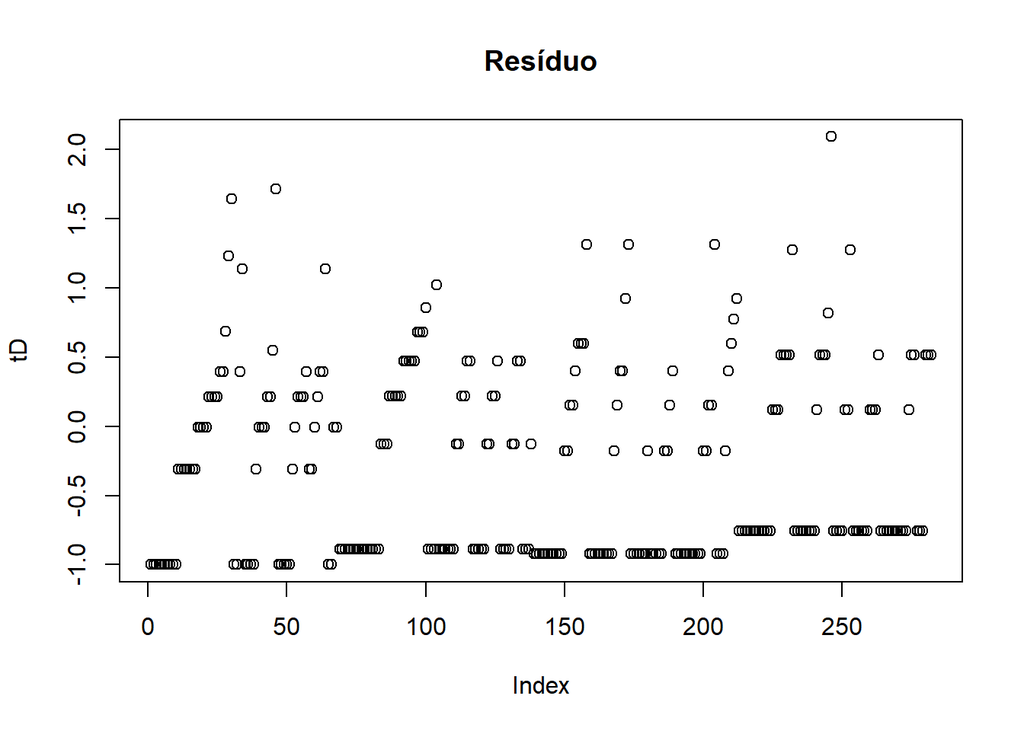

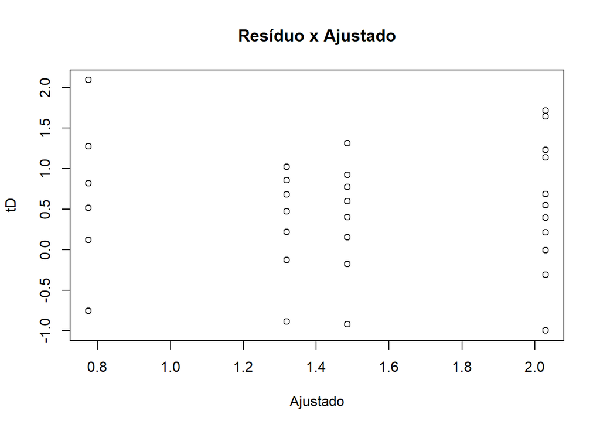

```r
modelo<-infeccoes ~ local + nadar
fit.model <- glm.nb(modelo,link=identity)
resul.resd<-residuosBN(fit.model)
```

Os resíduos estão bem comportados, não foram identificados padrões.

**Código**

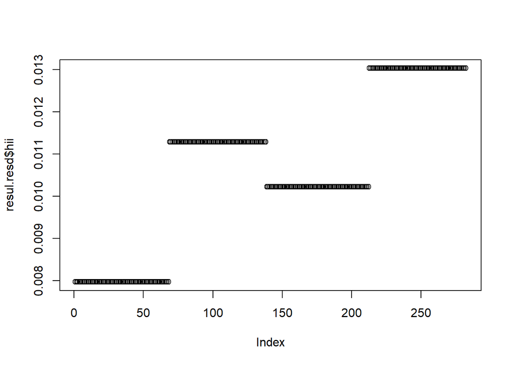

```r
plot(resul.resd$hii)
```

**Código**

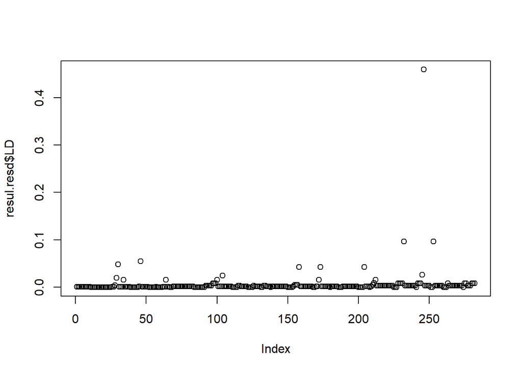

```r
plot(resul.resd$LD)
```

A observação 246 é a que exerce maior influência na verossimilhança.

**Código**

```r
recrutas[246,]
```

```
# A tibble: 1 × 5
  nadar local idade sexo   infeccoes
  <fct> <fct> <fct> <fct>      <dbl>
1 Freq  Beach 15-19 Female        10
```

**Código**

```r
summary(infeccoes)
```

```
   Min. 1st Qu.  Median    Mean 3rd Qu.    Max.
  0.000   0.000   0.000   1.411   2.000  17.000
```

## Interpretação

**Código**

```r
modelo<-infeccoes ~ local + nadar
fit.model <- glm.nb(modelo,link=identity)
coef(fit.model)
```

```
  (Intercept) localNonBeach    nadarOccas
    0.7750388     0.5442095     0.7100135
```

- Nadar na piscina comparado com nadar na praia aumenta em 0.54 unidades o número de infecções.
- Nadar ocasionalmente comparado com nadar frequentemente aumenta em 0.71 unidades o número de infecções.

# 20.

**Código**

```r
suppressMessages(nitrofen <- read_table("dados/lista4/nitrofen.txt",
                       col_names = FALSE))

colnames(nitrofen)<-c("dose","ovos")
nitrofen<-nitrofen[-51,]
nitrofen$dose<-as.factor(nitrofen$dose)
```

## Análise Exploratória

**Código**

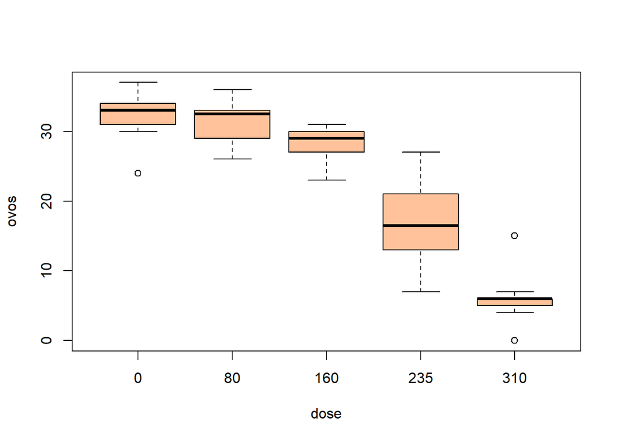

```r
suppressMessages(attach(nitrofen))
boxplot(ovos~dose, col=cores[3])
```

Doses maiores parecem reduzir o número de ovos eclodidos.

## Seleção do modelo

**Código**

```
[1] "Poisson-Link(log)"
```

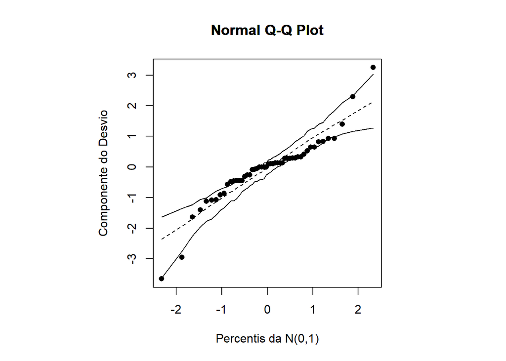

```
[1] "Poisson-Link(raiz)"
```

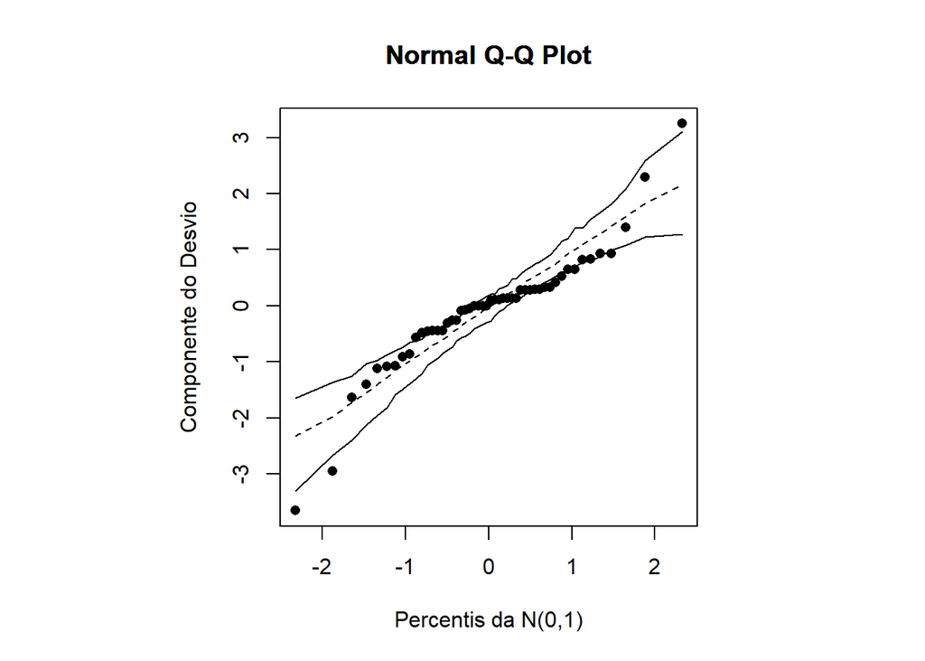

```
[1] "Poisson-Link(identity)"
```

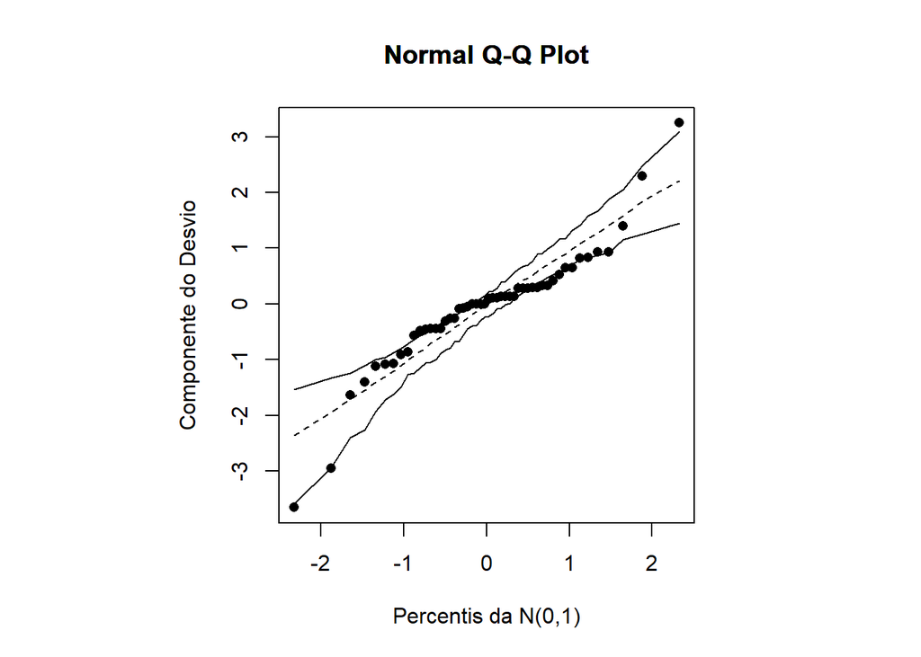

```r
n<-nrow(nitrofen)

modelo<-ovos~dose
pois<-rbind(
ResultadosPois(nitrofen, modelo, ligacao = "log", tipo ="envel_pois_log"),
ResultadosPois(nitrofen, modelo, ligacao = "raiz", tipo ="envel_pois_raiz"),
ResultadosPois(nitrofen, modelo, ligacao = "identity", tipo ="envel_pois")
)
```

**Código**

```r
pois |>
  arrange(BIC) |>
  knitr::kable(caption = "Melhor modelo - Poisson", format ="pipe")
```

Melhor modelo - Poisson

| Family | QQplot | BIC | Modelo |
| --- | --- | --- | --- |
| Poisson-Link(log) | Ruim | 307.6661 | ovos ~ dose |
| Poisson-Link(raiz) | Ruim | 307.6661 | ovos ~ dose |
| Poisson-Link(identity) | Ruim | 307.6661 | ovos ~ dose |

**Código**

```
[1] "Binomial Negativa - Link(log)"
```

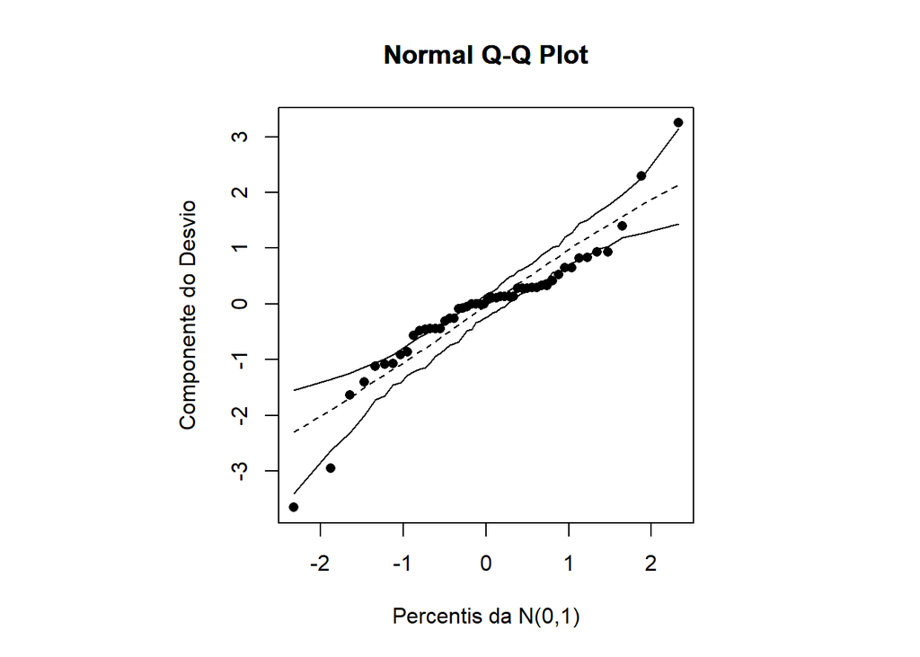

```
[1] "Binomial Negativa - Link(raiz)"
```

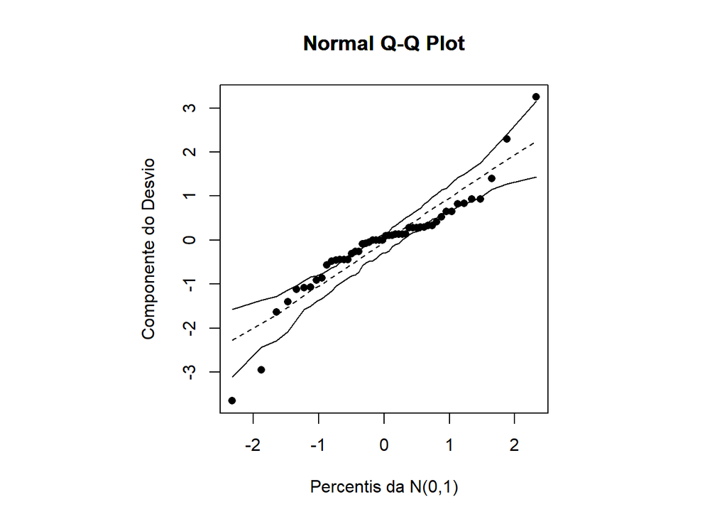

```
[1] "Binomial Negativa - Link(identity)"
```

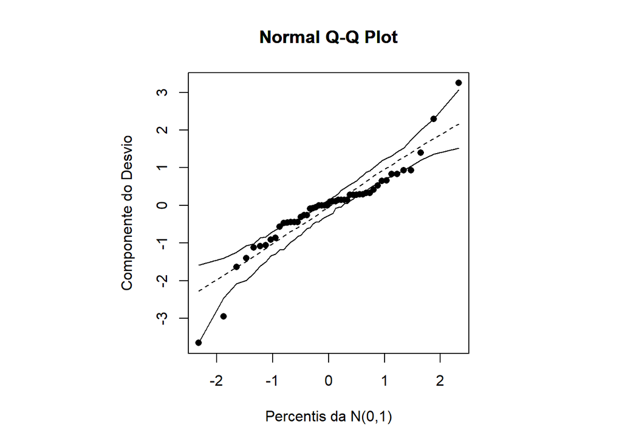

```r
bn<-rbind(
ResultadosBN(nitrofen, modelo, ligacao = "log", tipo ="envel_nbin_log"),
ResultadosBN(nitrofen, modelo, ligacao = "raiz", tipo ="envel_nbin_raiz"),
ResultadosBN(nitrofen, modelo, ligacao = "identity", tipo ="envel_nbin")
)
```

**Código**

```r
bn |>
  arrange(BIC) |>
  knitr::kable(caption = "Melhor modelo - Binomial Negativa", format ="pipe")
```

Melhor modelo - Binomial Negativa

| Family | QQplot | BIC | Modelo |
| --- | --- | --- | --- |
| Binomial Negativa - Link(log) | Ruim | 311.5799 | ovos ~ dose |
| Binomial Negativa - Link(raiz) | Ruim | 311.5799 | ovos ~ dose |
| Binomial Negativa - Link(identity) | Ruim | 311.5799 | ovos ~ dose |

## Teste de adequação da função de ligação

**Código**

```r
modelo<-ovos~dose
fit.model <- glm(modelo, family=poisson(link=log))
pl2 <- predict(fit.model)^2
fit.model2<-glm(update.formula(modelo,~ . + pl2), family=poisson(link=log))
summary(fit.model2)
```

```
Call:
glm(formula = update.formula(modelo, ~. + pl2), family = poisson(link = log))

Coefficients: (1 not defined because of singularities)
            Estimate Std. Error z value Pr(>|z|)
(Intercept)  3.47816    0.05556  62.607  < 2e-16 ***
dose80      -0.02817    0.07913  -0.356   0.7218
dose160     -0.13530    0.08136  -1.663   0.0963 .
dose235     -0.63325    0.09434  -6.712 1.92e-11 ***
dose310     -1.68640    0.14055 -11.999  < 2e-16 ***
pl2               NA         NA      NA       NA
---
Signif. codes:  0 '***' 0.001 '**' 0.01 '*' 0.05 '.' 0.1 ' ' 1

(Dispersion parameter for poisson family taken to be 1)

    Null deviance: 319.02  on 49  degrees of freedom
Residual deviance:  50.70  on 45  degrees of freedom
AIC: 298.11

Number of Fisher Scoring iterations: 5
```

**Código**

```r
table(dose,pl2)   # nao dah para fazer para uma unica variavel explicativa categorica
```

```
     pl2
dose  3.21040199556841 8.09350940214373 11.1747250449825 11.9024140663931
  0                  0                0                0                0
  80                 0                0                0               10
  160                0                0               10                0
  235                0               10                0                0
  310               10                0                0                0
     pl2
dose  12.0975860140827
  0                 10
  80                 0
  160                0
  235                0
  310                0
```

O teste não funciona, só temos uma variável explicativa e ela é categórica.

## Resíduos e Diagnóstico

**Código**

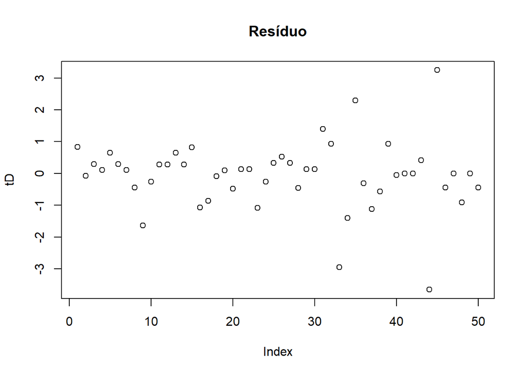

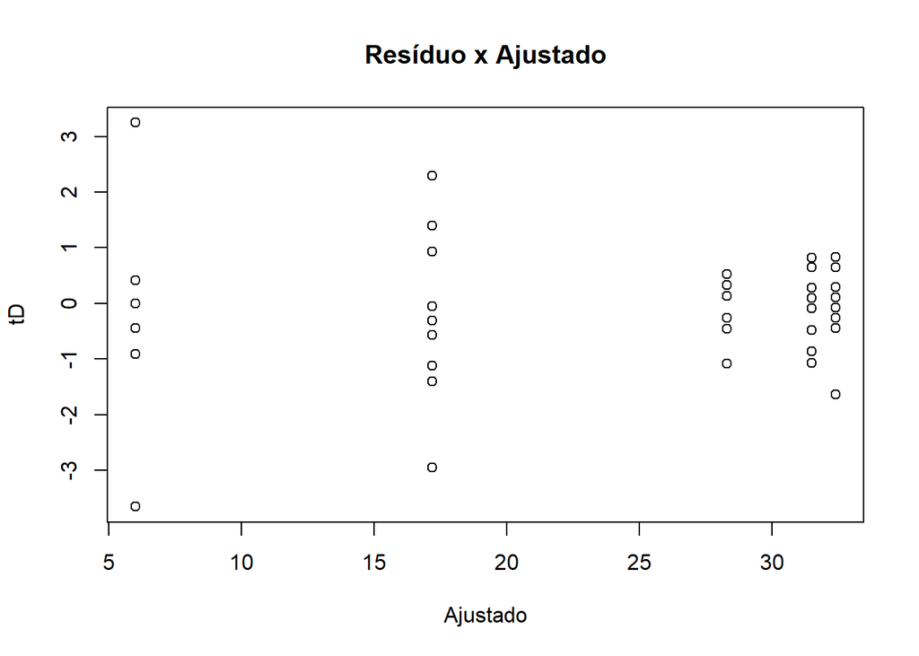

```r
modelo<-ovos~dose
fit.model <- glm(modelo, family=poisson(link=log))

resul.resd<-residuos(fit.model)
```

Tirando as duas observações que possuem resíduos altos, os resíduos estão bem comportados.

**Código**

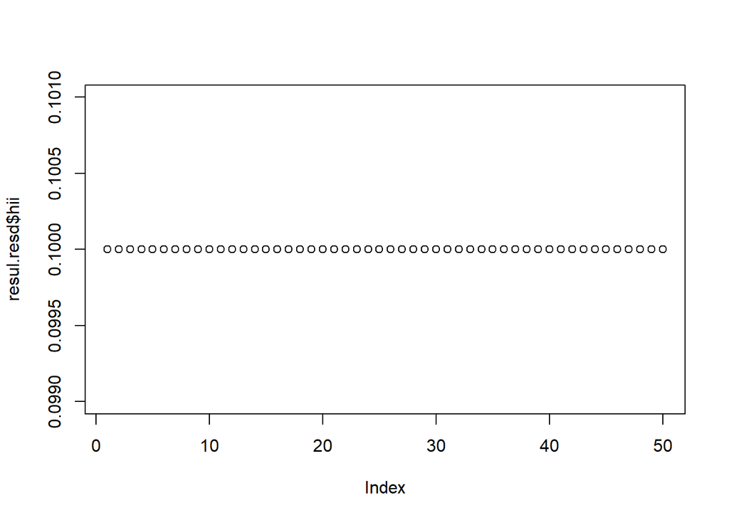

```r
plot(resul.resd$hii)
```

**Código**

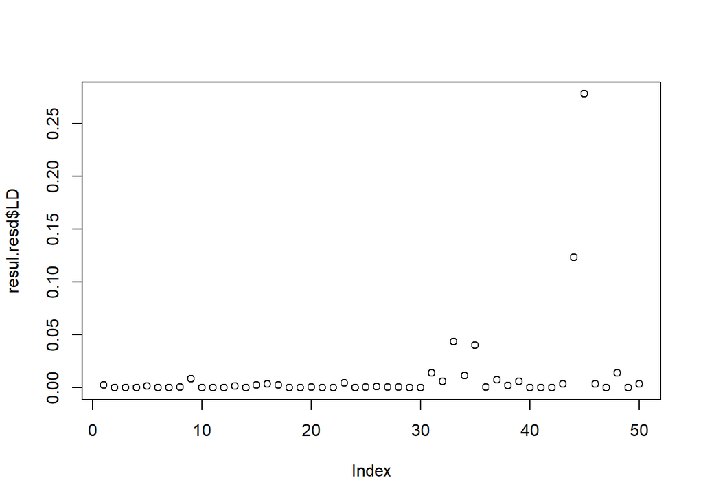

```r
plot(resul.resd$LD)
```

**Código**

```r
summary(ovos)
```

```
   Min. 1st Qu.  Median    Mean 3rd Qu.    Max.
   0.00   15.00   27.00   23.08   31.75   37.00
```

**Código**

```r
nitrofen[45,]
```

```
# A tibble: 1 × 2
  dose   ovos
  <fct> <dbl>
1 310      15
```

A observação 45 está no primeiro quartil da variável resposta e recebeu a maior dose.

## Interpretação

**Código**

```r
modelo<-modelo<-ovos~dose
fit.model <- glm(modelo, family=poisson(link=log))
exp(coef(fit.model))
```

```
(Intercept)      dose80     dose160     dose235     dose310
 32.4000000   0.9722222   0.8734568   0.5308642   0.1851852
```

- A dose de 80mg/l de nitrofen reduz em 3% o número de ovos que eclodiram.
- A dose de 160mg/l reduz em 13%.
- A dose de 235mg/l reduz em 47%.
- A dose mais eficaz em reduzir o número de ovos é a de 310mg/l, reduz em 81%.